# Local ancestry inference with hapla

**Purpose.** Admixture proportions say *how much* of a genome comes from each ancestral population. **Local** ancestry asks *where*: along the chromosome, which stretch came from which source. That is what tells you when the admixture happened, since recombination breaks the ancestry tracts down over generations.

**What you will do**

- simulate an admixed population with `msprime`, so the true ancestry is known
- cluster haplotypes with `hapla cluster` and see what the window size does
- estimate admixture proportions from the clusters with `hapla admix`
- infer local ancestry along the chromosome with `hapla fatash`, and compare the inferred tracts with the truth
- apply the same pipeline to a real cattle dataset

**Before this** do Admixture proportions from called genotypes, which estimates the genome-wide proportions this exercise localises.

## Setup

All the paths used by this exercise are set in the cell below.

```
#############################################################
# ALL PATHS ARE SET HERE
# If the data or the software moves, this is the ONLY cell you
# need to change. No cell below this one uses a full path.
#############################################################

# where the shared data lives
DATA=/course/data/current_data/local_ancestry/hapla_cattle

# the output of the msprime simulation, run once and saved so you do not have to
SIM=$DATA/simulated

# where you will do the exercise
WORK_DIR=$HOME/local_ancestry_hapla

mkdir -p $WORK_DIR
cd $WORK_DIR

# the cells below read the paths back out of this file, so they are only set here
echo "export DATA=$DATA"       >  $WORK_DIR/env.sh
echo "export SIM=$SIM"         >> $WORK_DIR/env.sh
echo "export WORK=$WORK_DIR"   >> $WORK_DIR/env.sh

# the cattle dataset used at the end of the exercise
CATTLE_BCF=$DATA/Chr25.314inds.imputated.BosTau9.bcf
CATTLE_INDS=$DATA/F1.pure.inds

echo --programs that are installed:--
which hapla
which bcftools

echo; echo --- cattle data ---
ls -la $CATTLE_BCF
```

```
# R cannot source env.sh, so read the paths out of it rather than repeating them
env <- readLines(path.expand("~/local_ancestry_hapla/env.sh"))
getvar <- function(k) sub(paste0('^export ', k, '='), '', grep(paste0('^export ', k, '='), env, value = TRUE)[1])
DATA <- getvar("DATA"); WORK <- getvar("WORK")
setwd(WORK)
getwd()
```

```
# Python reads the same file, so the paths are still only set in the cell above
import os
env = dict(l.strip().removeprefix("export ").split("=", 1)
           for l in open(os.path.expanduser("~/local_ancestry_hapla/env.sh")) if "=" in l)
DATA, WORK = env["DATA"], env["WORK"]
os.chdir(WORK)
```

```
which hapla
hapla -h
```

```
/usr/local/bin/hapla
usage: hapla [-h] {cluster,predict,struct,admix,fatash} ...

options:
  -h, --help            show this help message and exit

hapla commands:
  {cluster,predict,struct,admix,fatash}
```

## Simulating the data

The exercise runs on simulated data: 100 megabases, about the size of a medium human chromosome, for four populations under a specific demographic model. The simulation gives us phased BCF files plus the **true** ancestry of every segment, which is what lets us check how well the inference did — with real data you never know the answer.

The code that does it is in the next cell, **commented out**. It takes about 15 minutes to run, so it was run once and its output saved with the rest of the data. The cell after it copies that output into your working folder, which takes a second.

You do not need to follow the code in detail. If you want to run it yourself, uncomment it and skip the copy cell.

```
# import os
# import numpy as np
# import time
# import subprocess
# import pandas as pd
#
# import demes
# import msprime
# import tspop
#
#
# t0 = time.time()
#
# sequence_length = 1e8
# seed = 1337
# rho = 1.3e-8 ## Recombination rate
# mu = 1.25e-8  ## Mutation rate
#
# ## Make the Demography object.
# graph = demes.load(os.path.join(DATA, "aa.yaml"))
# demography = msprime.Demography.from_demes(graph)
# demography.add_census(time=13)
# demography.sort_events()
#
#
# ## Simulate.
# ts = msprime.sim_ancestry(
#     samples={"AFR": 100, "EUR": 100, "EAS": 100 ,"ADMIX" : 100},
#     demography=demography,
#     random_seed=seed,
#     sequence_length=sequence_length,
#     recombination_rate=rho
# )
#
# ## Simulate mutations on the tree sequence.
# mutated_ts = msprime.sim_mutations(ts, rate=mu, random_seed=seed)
#
# ## Define the output VCF and BCF file paths.
# vcf_file_path = "simAA.vcf"
# bcf_file_path = "simAA_maf.bcf"
#
# ## Save the mutated tree sequence to a VCF file.
# with open(vcf_file_path, "w") as vcf_file:
#     mutated_ts.write_vcf(vcf_file, individual_names=[f"{pop}_{i}" for pop in ["AFR", "EUR", "EAS", "ADMIX"] for i in range(1, 101)])
#
# ## Convert VCF to BCF and filter on minor allele freq
# subprocess.run(["bcftools", "+fill-tags", vcf_file_path, "-O", "b", "-o", "simAA.bcf", "--", "-t", "MAF"])
#
# subprocess.run(["bcftools", "view", "simAA.bcf", "-O", "b", "-o", bcf_file_path, "-i", "INFO/MAF > 0.05"])
#
# subprocess.run(["rm", vcf_file_path])
#
# subprocess.run(["bcftools", "index", "simAA.bcf"])
# subprocess.run(["bcftools", "index", bcf_file_path])
#
#
# pa = tspop.get_pop_ancestry(ts, census_time=13)
# ## print(pa)
#
# st = pa.squashed_table
# ## print(st)
#
# ## Remap numbering of populations to order of sampled pops
# remap = {2: 0, 4: 1, 5: 2}
# st = st.replace({"population": remap})
#
# st_path = "simAA_true_anc.csv"
# st.to_csv(st_path, sep="\t", index=False)
#
# st["tract_len"] = st["right"] - st["left"]
#
# st['sample'] = st['sample'] // 2 ## switch to individual numbering, instead of haplotype
# st_agg = st[['sample', 'population', 'tract_len']].groupby(['sample', 'population'], as_index=False).sum()
# st_pivoted = st_agg.pivot(index='sample', columns='population', values='tract_len').fillna(0)
# Q = st_pivoted.div(st_pivoted.sum(axis=1), axis=0).to_numpy()
# np.savetxt("simAA_trueQ.csv", Q, delimiter="\t", fmt='%.4f')
#
#
# t1 = time.time()
# print(f"Seconds elapsed: {t1-t0}")
```

```
source ~/local_ancestry_hapla/env.sh
cd $WORK

# copy the output of the simulation above, instead of running it
cp -f $SIM/simAA.bcf $SIM/simAA.bcf.csi .
cp -f $SIM/simAA_maf.bcf $SIM/simAA_maf.bcf.csi .
cp -f $SIM/simAA_true_anc.csv $SIM/simAA_trueQ.csv .

ls -lh simAA*
```

```
-rw-r--r-- 1 albrecht admin  25M Sep 17 10:10 simAA.bcf
-rw-r--r-- 1 albrecht admin  60K Sep 17 10:10 simAA.bcf.csi
-rw-r--r-- 1 albrecht admin  11M Sep 17 10:10 simAA_maf.bcf
-rw-r--r-- 1 albrecht admin  49K Sep 17 10:10 simAA_maf.bcf.csi
-rw-r--r-- 1 albrecht admin  69K Sep 17 10:10 simAA_true_anc.csv
-rw-r--r-- 1 albrecht admin 8.3K Sep 17 10:10 simAA_trueQ.csv
```

## Lets just have a quick look at the data we generated for good measure:

```
bcftools view simAA.bcf | head -n20
bcftools view simAA.bcf -h | wc -l
```

```
##fileformat=VCFv4.2
##FILTER=<ID=PASS,Description="All filters passed">
##source=tskit 0.6.4
##contig=<ID=1,length=100000000>
##FORMAT=<ID=GT,Number=1,Type=String,Description="Genotype">
##INFO=<ID=MAF,Number=1,Type=Float,Description="Frequency of the second most common allele">
##bcftools_pluginVersion=1.13+htslib-1.13+ds
##bcftools_pluginCommand=plugin fill-tags -O b -o simAA.bcf -- simAA.vcf -t MAF; Date=Thu Sep 17 09:35:51 2026
##bcftools_viewVersion=1.13+htslib-1.13+ds
##bcftools_viewCommand=view simAA.bcf; Date=Thu Sep 17 10:10:58 2026
#CHROM	POS	ID	REF	ALT	QUAL	FILTER	INFO	FORMAT	AFR_1	AFR_2	AFR_3	AFR_4	AFR_5	AFR_6	AFR_7	AFR_8	AFR_9	AFR_10	AFR_11	AFR_12	AFR_13	AFR_14	AFR_15	AFR_16	AFR_17	AFR_18	AFR_19	AFR_20	AFR_21	AFR_22	AFR_23	AFR_24	AFR_25	AFR_26	AFR_27	AFR_28	AFR_29	AFR_30	AFR_31	AFR_32	AFR_33	AFR_34	AFR_35	AFR_36	AFR_37	AFR_…
1	52	0	T	C	.	PASS	MAF=0.00125	GT	0|0	0|0	0|0	0|0	0|0	0|0	0|0	0|0	0|0	0|0	0|0	0|0	0|0	0|0	0|0	0|0	0|0	0|0	0|0	0|0	0|0	0|0	0|0	0|0	0|0	0|0	0|0	0|0	0|0	0|0	1|0	0|0	0|0	0|0	0|0	0|0	0|0	0|0	0|0	0|0	0|0	0|0	0|0	0|0	0|0	0|0	0|0	0|0	0|0	0|0	0|0	0|0	0|0	0|0	0|0	0|0	0|0	0|0	0|0	0|0	0|0	0|0	0|0	0|0	0|0	0|0	0|0…
1	178	1	C	T	.	PASS	MAF=0.00125	GT	0|0	0|0	0|0	0|0	0|0	0|0	0|0	0|0	0|0	0|0	0|0	0|0	0|0	0|0	0|0	0|0	0|0	0|0	0|0	0|0	0|0	0|0	0|0	0|0	0|0	0|0	0|0	0|0	0|0	0|0	0|0	0|0	0|0	0|0	0|0	0|0	0|0	0|0	0|0	0|0	0|0	0|0	0|0	0|0	0|0	0|0	0|0	0|0	0|0	0|0	0|0	0|0	0|0	0|0	0|0	0|0	0|0	0|0	0|0	0|0	0|0	0|0	0|0	0|0	0|0	0|0	0|…
1	301	2	A	T	.	PASS	MAF=0.0025	GT	0|0	0|0	0|0	0|0	0|0	0|0	0|0	0|0	0|0	0|0	0|0	0|0	0|0	0|0	0|0	0|0	0|0	0|0	0|0	0|0	0|0	0|0	0|0	0|0	0|0	0|0	0|0	0|0	0|0	0|0	0|0	0|0	0|0	0|0	0|0	0|0	0|0	0|0	0|0	0|0	0|0	0|0	0|0	0|0	0|0	0|0	0|0	0|1	0|0	0|0	0|0	0|0	0|0	0|0	0|0	0|0	0|0	0|0	0|0	0|0	0|0	0|0	0|0	0|0	0|0	0|0	0|0…
1	339	3	G	A	.	PASS	MAF=0.2975	GT	0|0	0|1	1|0	0|0	0|1	0|0	0|1	0|0	1|0	0|1	0|0	1|1	0|0	1|0	0|1	1|0	1|1	0|0	0|0	0|1	0|0	1|0	1|0	0|0	0|0	0|0	1|0	1|1	1|0	0|0	0|0	1|0	0|0	0|0	0|1	0|0	0|0	1|0	0|1	0|0	0|0	1|0	1|0	0|0	0|1	0|1	0|1	1|0	0|1	1|0	0|1	0|1	0|0	0|1	0|0	0|0	1|0	1|0	0|1	0|1	0|0	1|0	1|1	0|0	0|0	0|1	0|0…
1	403	4	A	C	.	PASS	MAF=0.09	GT	1|1	1|1	1|1	1|1	1|1	1|0	1|1	0|1	1|1	1|1	1|1	1|1	0|1	1|1	1|1	1|1	1|1	1|1	1|0	1|1	1|1	1|1	1|1	1|1	1|1	1|1	1|0	1|1	1|1	0|1	1|1	1|1	1|1	1|0	1|1	1|1	1|1	1|1	0|1	0|1	0|1	1|1	1|1	1|1	0|1	1|1	1|1	1|0	1|1	1|1	0|1	1|1	1|0	1|1	1|1	0|1	1|1	1|1	1|1	1|1	1|1	1|1	1|1	1|1	0|1	1|1	1|0	1…
1	695	5	C	T	.	PASS	MAF=0.00125	GT	0|0	0|0	0|0	0|0	0|0	0|0	0|0	0|0	0|0	0|0	0|0	0|0	0|0	0|0	0|0	0|0	0|0	0|0	0|0	0|0	0|0	0|0	0|0	0|0	0|0	0|0	0|0	0|0	0|0	0|0	0|0	0|0	0|0	0|0	0|0	0|0	0|0	0|0	0|0	0|0	0|0	0|0	0|0	0|0	0|0	0|0	0|0	0|0	0|0	0|0	0|0	0|0	0|0	0|0	0|0	0|0	0|0	0|0	0|0	0|0	0|0	0|0	0|0	0|0	0|0	0|0	0|…
1	818	6	G	C	.	PASS	MAF=0.01375	GT	0|0	0|0	0|0	0|0	0|0	0|1	0|0	0|0	0|0	0|0	0|0	0|0	1|0	0|0	0|0	0|0	0|0	0|0	0|1	0|0	0|0	0|0	0|0	0|0	0|0	0|0	0|0	0|0	0|0	0|0	0|0	0|0	0|0	0|0	0|0	0|0	0|0	0|0	0|0	0|0	0|0	0|0	0|0	0|0	0|0	0|0	0|0	0|0	0|0	0|0	0|0	0|0	0|0	0|0	0|0	1|0	0|0	0|0	0|0	0|0	0|0	0|0	0|0	0|0	1|0	0|0	0|…
1	974	7	A	G	.	PASS	MAF=0.1225	GT	1|1	1|1	1|0	1|1	0|1	1|0	1|1	1|1	1|1	1|1	0|1	1|1	0|1	1|1	1|1	1|1	1|1	1|1	1|0	1|1	1|0	1|1	1|1	0|1	1|0	1|1	1|0	1|1	1|0	0|1	1|1	1|1	1|1	1|1	1|1	1|1	1|0	1|1	1|1	1|0	0|0	1|1	1|1	1|0	1|1	1|1	1|1	1|0	0|1	1|1	0|1	1|1	0|1	1|1	1|1	0|1	1|1	1|0	1|1	0|1	1|1	1|1	1|1	0|1	0|1	0|1	1|0…
1	1003	8	T	G	.	PASS	MAF=0.14625	GT	0|0	1|0	0|0	0|0	0|0	1|0	1|0	0|0	0|0	0|0	0|0	0|0	0|1	0|0	0|0	0|0	0|0	1|0	0|0	0|0	1|0	0|0	0|0	0|1	0|0	1|1	0|0	0|0	0|0	0|1	1|1	0|1	0|0	0|0	1|0	1|1	1|0	0|0	0|0	0|0	0|0	0|1	0|0	0|0	0|0	0|0	1|0	0|0	0|0	0|1	0|0	0|0	0|0	1|0	1|1	0|1	0|1	0|0	0|0	0|0	0|1	0|0	0|0	0|0	0|1	0|0	1…
[main_vcfview] Error: cannot write to (null)
11
```

**Questions**

- How many individuals and how many variants were simulated?
- Why simulate rather than start from real data?

## Do you recognize the format?

## What do the different fields in the header line mean?

## Do you remember what MAF is short for?

## Can you see how many individuas we are working with, either from the cell output above or the simulation script?

## Simulating our dataset here allows us to know the underlying true ancestry to compare with, that we would never be able to know completely with real data. The scenario from which our samples have been generated is a commonly used one which tries to approximate part of human demography for modern American admixture between source populations from Africa, Europe and East Asia (Browning et al. 2018), it can also be visualized with the following snippet:

```
import os
import msprime
import demes
import demesdraw
import matplotlib.pyplot as plt


## Make the Demography object.
graph = demes.load(os.path.join(DATA, "aa.yaml"))

fig, ax = plt.subplots(figsize=(10, 8))
demesdraw.tubes(graph, ax=ax)
ax.set_yscale('symlog')
ax.set_xlabel("Population Size")
ax.set_ylabel("Time (log scale)")
plt.show()
```

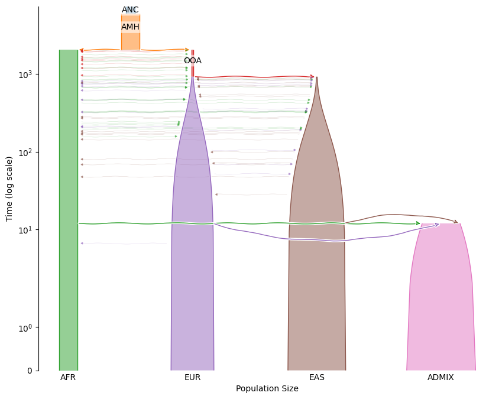

## And here we see first an ancient human population (also in Africa) followed by anatomically modern humans and then a split out of Africa with a small population size (bottleneck) and then a subsequent split into European and East Asian populations, with continous ongoing migration between the source populations and an increase in population sizes through the generations(the Y-scale here is measured in generations). Lastly we have an admixture event in recent history forming a modern american population and it is the samples from this population that we will try to infer ancestry in.

## The .yaml file which we load the demographic scenario in from looks like this:

```
cat $DATA/aa.yaml
```

```
time_units: generations
generation_time: 1
demes:
- name: ANC
  description: Ancestral equilibrium
  epochs:
  - {end_time: 5920, start_size: 7310}
- name: AMH
  description: Anatomically modern humans
  ancestors: [ANC]
  epochs:
  - {end_time: 2040, start_size: 14474}
- name: AFR
  description: African
  ancestors: [AMH]
  epochs:
  - {end_time: 0, start_size: 14474}
- name: OOA
  description: Bottleneck out-of-Africa
  ancestors: [AMH]
  epochs:
  - {end_time: 920, start_size: 1861}
- name: EUR
  description: European
  ancestors: [OOA]
  epochs:
  - {end_time: 0, start_size: 1032.0085233345426, end_size: 34039}
- name: EAS
  description: East Asian
  ancestors: [OOA]
  epochs:
  - {end_time: 0, start_size: 554.0052134346703, end_size: 45852}
- name: ADMIX
  description: Admixed America
  start_time: 12
  ancestors: [AFR, EUR, EAS]
  proportions: [0.16666666666666666, 0.3333333333333333, 0.5]
  epochs:
  - {end_time: 0, start_size: 30000.23927544386, end_size: 54664}
migrations:
- demes: [AFR, OOA]
  rate: 0.00015
- demes: [AFR, EUR]
  rate: 2.5e-05
- demes: [AFR, EAS]
  rate: 7.8e-06
- demes: [EUR, EAS]
  rate: 3.11e-05
```

## From the above, can you tell how much ancestry on average we would expect in a randomly sampled individual in the admixed population? (look for "proportions:")

## We will be working with just a single simulated contigous chromosome, but of course in the real world we run this for all available chromosomes. Now the first thing we need to do is to run the clustering module which will turn our perfectly phased bcf file into cluster assignments for each individual over windows with size 8:

```
hapla cluster --bcf simAA.bcf --size 8 --threads 8 --out simAA_wdsize8
```

```
-----------------------------------
hapla by Jonas Meisner (v0.40.0)
hapla cluster using 8 thread(s)
-----------------------------------

Loaded phased genotype data: 800 haplotypes and 600529 SNPs.
Clustering 75066 non-overlapping windows of 8 SNPs.
Window 75066/75066.

Saved haplotype clusters in binary format:
- simAA_wdsize8.bca
- simAA_wdsize8.ids
- simAA_wdsize8.win

Total parsing time: 0m14s
Total elapsed time: 1m13s
```

**Questions**

- `--size 8` sets the window size in variants. What is `hapla cluster` actually doing within a window?
- How many clusters does it find, and is that what you expected?

```
hapla cluster --bcf simAA_maf.bcf --size 8 --threads 8 --out simAA_maf_wdsize8
```

```
-----------------------------------
hapla by Jonas Meisner (v0.40.0)
hapla cluster using 8 thread(s)
-----------------------------------

Loaded phased genotype data: 800 haplotypes and 106171 SNPs.
Clustering 13271 non-overlapping windows of 8 SNPs.
Window 13271/13271.

Saved haplotype clusters in binary format:
- simAA_maf_wdsize8.bca
- simAA_maf_wdsize8.ids
- simAA_maf_wdsize8.win

Total parsing time: 0m2s
Total elapsed time: 0m18s
```

**Question**

- This run uses the MAF-filtered data. Why do rare variants make haplotype clustering harder?

## The next step will be to use these cluster assignments to infer admixture proportions (Q) and source population cluster frequencies (P, formerly F) for our data. But first lets have a look at the output we have generated so far. The .win contains information about each window, the .ids file list the order of appearance of samples by their ID/name and the .bca file contains the bulk of our data which is our cluster assignments in binary format:

```
ls -l -h
```

```
total 105M
-rw-r--r-- 1 albrecht admin  212 Sep 17 10:10 env.sh
-rw-r--r-- 1 albrecht admin  25M Sep 17 10:10 simAA.bcf
-rw-r--r-- 1 albrecht admin  60K Sep 17 10:10 simAA.bcf.csi
-rw-r--r-- 1 albrecht admin  11M Sep 17 10:10 simAA_maf.bcf
-rw-r--r-- 1 albrecht admin  49K Sep 17 10:10 simAA_maf.bcf.csi
-rw-r--r-- 1 albrecht admin  11M Sep 17 10:13 simAA_maf_wdsize8.bca
-rw-r--r-- 1 albrecht admin 2.9K Sep 17 10:13 simAA_maf_wdsize8.ids
-rw-r--r-- 1 albrecht admin  378 Sep 17 10:13 simAA_maf_wdsize8.log
-rw-r--r-- 1 albrecht admin 381K Sep 17 10:13 simAA_maf_wdsize8.win
-rw-r--r-- 1 albrecht admin  69K Sep 17 10:10 simAA_true_anc.csv
-rw-r--r-- 1 albrecht admin 8.3K Sep 17 10:10 simAA_trueQ.csv
-rw-r--r-- 1 albrecht admin  58M Sep 17 10:12 simAA_wdsize8.bca
-rw-r--r-- 1 albrecht admin 2.9K Sep 17 10:12 simAA_wdsize8.ids
-rw-r--r-- 1 albrecht admin  358 Sep 17 10:12 simAA_wdsize8.log
-rw-r--r-- 1 albrecht admin 2.1M Sep 17 10:12 simAA_wdsize8.win
```

```
head simAA_maf_wdsize8.win
```

```
#CHROM	START	END	LENGTH	SIZE	K
1	339	2948	2609	8	8
1	3159	10979	7820	8	11
1	12056	18778	6722	8	11
1	19787	25988	6201	8	11
1	26011	31905	5894	8	12
1	32493	40862	8369	8	10
1	41311	45865	4554	8	7
1	46317	55494	9177	8	12
1	55507	60078	4571	8	4
```

## Can you make sense of these fields?

## Why do the Lengths of each window differ?

## K is the number of clusters found for each window, lets have a look at our distribution of Ks:

```
tail -n+2 simAA_maf_wdsize8.win | cut -f6 | sort -n -r | uniq -c
```

```
      1 24
      1 23
      1 22
     11 20
     24 19
     33 18
     65 17
    130 16
    231 15
    393 14
    678 13
   1016 12
   1445 11
   1870 10
   2048 9
   2017 8
   1551 7
   1018 6
    473 5
    217 4
     46 3
      2 2
```

## What is the most common number of clusters across all windows?

## 24 clusters might sound like a lot, but with 8 SNPs in a window we will have 2<sup>8</sup> = 256 different possible haplotypes which puts this number into perspective.

## Next step is to run admixture inference on our clustered haplotypes, the order in which Ks are assigned is arbitrary and so Ive set the seed to 6 because this makes our results match the order saved for the true ancestries. This makes the plotting a little smoother. Note here that usually we would also need to run the admixture part multiple times to ensure convergence, but we will skip this part here, dont tell Anders.

```
hapla admix --clusters simAA_maf_wdsize8 --K 3 --seed 6 --threads 8 --out simAA_maf_wdsize8
```

```
-----------------------------------
hapla by Jonas Meisner (v0.40.0)
hapla admix using 8 thread(s)
-----------------------------------
Estimating ancestry proportions.
K=3, seed=6, batches=16

Parsing 1 file(s).
Loaded haplotype cluster assignments:
- 400 samples
- 13271 windows
- 124000 clusters

SVD/ALS initialization.		(2.4s)
Initial log-like: -15022327.7
Priming iteration.		(0.1s)

Mini-batch accelerated EM algorithm.
Using 16 mini-batches.
(5)	Log-like: -14978315.0	(0.7s)
(10)	Log-like: -14978291.9	(0.7s)
(15)	Log-like: -14978299.5	(0.7s)
Halving mini-batches to 8.
(20)	Log-like: -14978255.4	(0.7s)
(25)	Log-like: -14978266.9	(0.7s)
Halving mini-batches to 4.
(30)	Log-like: -14978248.3	(0.7s)
(35)	Log-like: -14978247.8	(0.7s)
(40)	Log-like: -14978248.9	(0.6s)
Halving mini-batches to 2.
(45)	Log-like: -14978239.2	(0.6s)
(50)	Log-like: -14978239.2	(0.7s)
Running standard updates.
(55)	Log-like: -14978237.3	(0.5s)
(60)	Log-like: -14978237.3	(0.4s)
Converged!

Final log-likelihood: -14978237.3
Saved Q matrix as simAA_maf_wdsize8.K3.s6.Q
Saved P matrix as simAA_maf_wdsize8.K3.s6.P

Total elapsed time: 0m11s
```

**Question**

- `hapla admix` works from the cluster assignments rather than from the genotypes. What does that buy you?

## And now lets have a look at the output, our new P and Q matrices:

```
head simAA_maf_wdsize8.K3.s6.P
```

```
0.289320 0.198275 0.000026
0.075920 0.091774 0.081247
0.203667 0.133134 0.361042
0.189160 0.041217 0.520627
0.241842 0.200257 0.023243
0.000030 0.183422 0.000026
0.000030 0.125713 0.013763
0.000030 0.026208 0.000026
0.426425 0.222189 0.102366
0.084480 0.187449 0.000026
```

```
wc -l simAA_maf_wdsize8.K3.s6.P
```

```
124000 simAA_maf_wdsize8.K3.s6.P
```

## Why do we have 3 columns in our P matrix?

## What is the number of rows and why do we have so many compared to the number of windows?

## If you cant figure out the previos question, try running this next line of code and try to figure out what it does. (the "| paste -sd+ | bc" part just sums up the numbers piped in)

```
cut -f6 simAA_maf_wdsize8.win | tail -n +2 | paste -sd+ | bc
```

```
124000
```

## And then our inferred admixture proportions from Q to see if they match our expectations from the demographic model:

```
options(repr.plot.width = 26)

popinfo <- gsub("[^A-Z]", "", read.table("simAA_maf_wdsize8.ids", h=F)[, 1])
Q <- read.table("simAA_maf_wdsize8.K3.s6.Q", h=F)

N <- length(popinfo)
popNames <- unique(popinfo)
Npop <- length(popNames)
popIDint <- rep(1:Npop,table(popinfo)[popNames])
popSep <- c(0,cumsum(table(popIDint)))
meanPopX <- popSep[-1]-table(popIDint)/2

barplot(t(Q), col=c("#b783c9", "#3eb05d", "#826746"), space=0, border=NA, cex.axis=1.2,cex.lab=1.8,axisnames=FALSE,
             ylab=paste0("Admixture proportions\nfor K = ", ncol(Q)), xlab="", main="", cex.main=1.5,xpd=NA)
text(meanPopX, rep(-0.15,length(meanPopX)), unique(popinfo),xpd=NA,font=2,cex=2)
abline(v=popSep)
popinfo
```

1. 'AFR'

2. 'AFR'

3. 'AFR'

4. 'AFR'

5. 'AFR'

6. 'AFR'

7. 'AFR'

8. 'AFR'

9. 'AFR'

10. 'AFR'

11. 'AFR'

12. 'AFR'

13. 'AFR'

14. 'AFR'

15. 'AFR'

16. 'AFR'

17. 'AFR'

18. 'AFR'

19. 'AFR'

20. 'AFR'

21. 'AFR'

22. 'AFR'

23. 'AFR'

24. 'AFR'

25. 'AFR'

26. 'AFR'

27. 'AFR'

28. 'AFR'

29. 'AFR'

30. 'AFR'

31. 'AFR'

32. 'AFR'

33. 'AFR'

34. 'AFR'

35. 'AFR'

36. 'AFR'

37. 'AFR'

38. 'AFR'

39. 'AFR'

40. 'AFR'

41. 'AFR'

42. 'AFR'

43. 'AFR'

44. 'AFR'

45. 'AFR'

46. 'AFR'

47. 'AFR'

48. 'AFR'

49. 'AFR'

50. 'AFR'

51. 'AFR'

52. 'AFR'

53. 'AFR'

54. 'AFR'

55. 'AFR'

56. 'AFR'

57. 'AFR'

58. 'AFR'

59. 'AFR'

60. 'AFR'

61. 'AFR'

62. 'AFR'

63. 'AFR'

64. 'AFR'

65. 'AFR'

66. 'AFR'

67. 'AFR'

68. 'AFR'

69. 'AFR'

70. 'AFR'

71. 'AFR'

72. 'AFR'

73. 'AFR'

74. 'AFR'

75. 'AFR'

76. 'AFR'

77. 'AFR'

78. 'AFR'

79. 'AFR'

80. 'AFR'

81. 'AFR'

82. 'AFR'

83. 'AFR'

84. 'AFR'

85. 'AFR'

86. 'AFR'

87. 'AFR'

88. 'AFR'

89. 'AFR'

90. 'AFR'

91. 'AFR'

92. 'AFR'

93. 'AFR'

94. 'AFR'

95. 'AFR'

96. 'AFR'

97. 'AFR'

98. 'AFR'

99. 'AFR'

100. 'AFR'

101. 'EUR'

102. 'EUR'

103. 'EUR'

104. 'EUR'

105. 'EUR'

106. 'EUR'

107. 'EUR'

108. 'EUR'

109. 'EUR'

110. 'EUR'

111. 'EUR'

112. 'EUR'

113. 'EUR'

114. 'EUR'

115. 'EUR'

116. 'EUR'

117. 'EUR'

118. 'EUR'

119. 'EUR'

120. 'EUR'

121. 'EUR'

122. 'EUR'

123. 'EUR'

124. 'EUR'

125. 'EUR'

126. 'EUR'

127. 'EUR'

128. 'EUR'

129. 'EUR'

130. 'EUR'

131. 'EUR'

132. 'EUR'

133. 'EUR'

134. 'EUR'

135. 'EUR'

136. 'EUR'

137. 'EUR'

138. 'EUR'

139. 'EUR'

140. 'EUR'

141. 'EUR'

142. 'EUR'

143. 'EUR'

144. 'EUR'

145. 'EUR'

146. 'EUR'

147. 'EUR'

148. 'EUR'

149. 'EUR'

150. 'EUR'

151. 'EUR'

152. 'EUR'

153. 'EUR'

154. 'EUR'

155. 'EUR'

156. 'EUR'

157. 'EUR'

158. 'EUR'

159. 'EUR'

160. 'EUR'

161. 'EUR'

162. 'EUR'

163. 'EUR'

164. 'EUR'

165. 'EUR'

166. 'EUR'

167. 'EUR'

168. 'EUR'

169. 'EUR'

170. 'EUR'

171. 'EUR'

172. 'EUR'

173. 'EUR'

174. 'EUR'

175. 'EUR'

176. 'EUR'

177. 'EUR'

178. 'EUR'

179. 'EUR'

180. 'EUR'

181. 'EUR'

182. 'EUR'

183. 'EUR'

184. 'EUR'

185. 'EUR'

186. 'EUR'

187. 'EUR'

188. 'EUR'

189. 'EUR'

190. 'EUR'

191. 'EUR'

192. 'EUR'

193. 'EUR'

194. 'EUR'

195. 'EUR'

196. 'EUR'

197. 'EUR'

198. 'EUR'

199. 'EUR'

200. 'EUR'

201. 'EAS'

202. 'EAS'

203. 'EAS'

204. 'EAS'

205. 'EAS'

206. 'EAS'

207. 'EAS'

208. 'EAS'

209. 'EAS'

210. 'EAS'

211. 'EAS'

212. 'EAS'

213. 'EAS'

214. 'EAS'

215. 'EAS'

216. 'EAS'

217. 'EAS'

218. 'EAS'

219. 'EAS'

220. 'EAS'

221. 'EAS'

222. 'EAS'

223. 'EAS'

224. 'EAS'

225. 'EAS'

226. 'EAS'

227. 'EAS'

228. 'EAS'

229. 'EAS'

230. 'EAS'

231. 'EAS'

232. 'EAS'

233. 'EAS'

234. 'EAS'

235. 'EAS'

236. 'EAS'

237. 'EAS'

238. 'EAS'

239. 'EAS'

240. 'EAS'

241. 'EAS'

242. 'EAS'

243. 'EAS'

244. 'EAS'

245. 'EAS'

246. 'EAS'

247. 'EAS'

248. 'EAS'

249. 'EAS'

250. 'EAS'

251. 'EAS'

252. 'EAS'

253. 'EAS'

254. 'EAS'

255. 'EAS'

256. 'EAS'

257. 'EAS'

258. 'EAS'

259. 'EAS'

260. 'EAS'

261. 'EAS'

262. 'EAS'

263. 'EAS'

264. 'EAS'

265. 'EAS'

266. 'EAS'

267. 'EAS'

268. 'EAS'

269. 'EAS'

270. 'EAS'

271. 'EAS'

272. 'EAS'

273. 'EAS'

274. 'EAS'

275. 'EAS'

276. 'EAS'

277. 'EAS'

278. 'EAS'

279. 'EAS'

280. 'EAS'

281. 'EAS'

282. 'EAS'

283. 'EAS'

284. 'EAS'

285. 'EAS'

286. 'EAS'

287. 'EAS'

288. 'EAS'

289. 'EAS'

290. 'EAS'

291. 'EAS'

292. 'EAS'

293. 'EAS'

294. 'EAS'

295. 'EAS'

296. 'EAS'

297. 'EAS'

298. 'EAS'

299. 'EAS'

300. 'EAS'

301. 'ADMIX'

302. 'ADMIX'

303. 'ADMIX'

304. 'ADMIX'

305. 'ADMIX'

306. 'ADMIX'

307. 'ADMIX'

308. 'ADMIX'

309. 'ADMIX'

310. 'ADMIX'

311. 'ADMIX'

312. 'ADMIX'

313. 'ADMIX'

314. 'ADMIX'

315. 'ADMIX'

316. 'ADMIX'

317. 'ADMIX'

318. 'ADMIX'

319. 'ADMIX'

320. 'ADMIX'

321. 'ADMIX'

322. 'ADMIX'

323. 'ADMIX'

324. 'ADMIX'

325. 'ADMIX'

326. 'ADMIX'

327. 'ADMIX'

328. 'ADMIX'

329. 'ADMIX'

330. 'ADMIX'

331. 'ADMIX'

332. 'ADMIX'

333. 'ADMIX'

334. 'ADMIX'

335. 'ADMIX'

336. 'ADMIX'

337. 'ADMIX'

338. 'ADMIX'

339. 'ADMIX'

340. 'ADMIX'

341. 'ADMIX'

342. 'ADMIX'

343. 'ADMIX'

344. 'ADMIX'

345. 'ADMIX'

346. 'ADMIX'

347. 'ADMIX'

348. 'ADMIX'

349. 'ADMIX'

350. 'ADMIX'

351. 'ADMIX'

352. 'ADMIX'

353. 'ADMIX'

354. 'ADMIX'

355. 'ADMIX'

356. 'ADMIX'

357. 'ADMIX'

358. 'ADMIX'

359. 'ADMIX'

360. 'ADMIX'

361. 'ADMIX'

362. 'ADMIX'

363. 'ADMIX'

364. 'ADMIX'

365. 'ADMIX'

366. 'ADMIX'

367. 'ADMIX'

368. 'ADMIX'

369. 'ADMIX'

370. 'ADMIX'

371. 'ADMIX'

372. 'ADMIX'

373. 'ADMIX'

374. 'ADMIX'

375. 'ADMIX'

376. 'ADMIX'

377. 'ADMIX'

378. 'ADMIX'

379. 'ADMIX'

380. 'ADMIX'

381. 'ADMIX'

382. 'ADMIX'

383. 'ADMIX'

384. 'ADMIX'

385. 'ADMIX'

386. 'ADMIX'

387. 'ADMIX'

388. 'ADMIX'

389. 'ADMIX'

390. 'ADMIX'

391. 'ADMIX'

392. 'ADMIX'

393. 'ADMIX'

394. 'ADMIX'

395. 'ADMIX'

396. 'ADMIX'

397. 'ADMIX'

398. 'ADMIX'

399. 'ADMIX'

400. 'ADMIX'

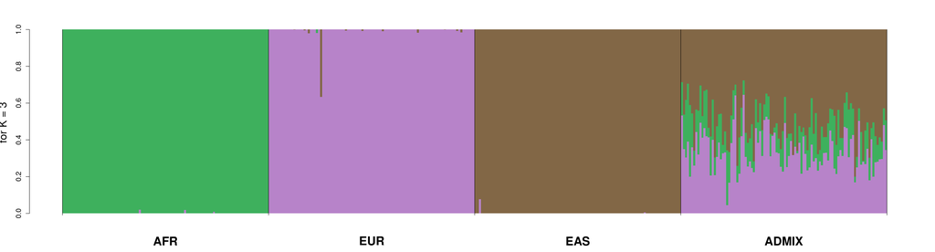

## Do you see any immediate problems here?

## And since we simulated our data we can also cheat a little and check against the true admixture proportions:

```
popinfo <- gsub("[^A-Z]", "", read.table("simAA_maf_wdsize8.ids", h=F)[, 1])

Q <- read.table("simAA_trueQ.csv", h=F)[, c(2,1,3)]

N <- length(popinfo)
popNames <- unique(popinfo)
Npop <- length(popNames)
popIDint <- rep(1:Npop,table(popinfo)[popNames])
popSep <- c(0,cumsum(table(popIDint)))
meanPopX <- popSep[-1]-table(popIDint)/2

barplot(t(Q), col=c("#b783c9", "#3eb05d", "#826746"), space=0, border=NA, cex.axis=1.2,cex.lab=1.8,axisnames=FALSE,
             ylab=paste0("Admixture proportions\nfor K = ", ncol(Q)), xlab="", main="", cex.main=1.5,xpd=NA)
text(meanPopX, rep(-0.15,length(meanPopX)), unique(popinfo),xpd=NA,font=2,cex=2)
abline(v=popSep)
```

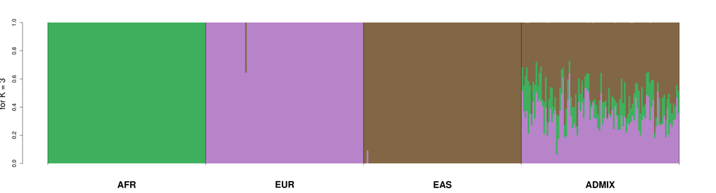

## What do you think of our inferred ancestry proportions? Can you spot any differences?

## Now we can start estimating local ancestry with the "fatash" module, where we use our observed cluster assignments and our Q and P matrices as input, and otherwise just default options:

```
hapla fatash --clusters simAA_maf_wdsize8 --qfile simAA_maf_wdsize8.K3.s6.Q --pfile simAA_maf_wdsize8.K3.s6.P --threads 8 --out simAA_maf_wdsize8
```

```
-----------------------------------
hapla by Jonas Meisner (v0.40.0)
hapla fatash using 8 thread(s)
-----------------------------------

Parsing 1 file(s).
Inferring local ancestry tracts from 3 ancestral sources.
Processing file 1/1
Estimating file-specific ancestry proportions.		(4.6s)
Performing posterior decoding with majority voting across 5 alphas.
Saved posterior decoding path as simAA_maf_wdsize8.path

Total elapsed time: 0m13s
```

**Questions**

- `hapla fatash` produces a path per haplotype. What does one row of the `.path` file describe?
- `--viterbi` picks the single most likely path. What is the alternative, and when would you prefer it?

## Now we get an output in the form of a .path file, which looks like this inside:

```
ls -l
```

```
total 131288
-rw-r--r-- 1 albrecht admin      212 Sep 17 10:10 env.sh
-rw-r--r-- 1 albrecht admin 25536440 Sep 17 10:10 simAA.bcf
-rw-r--r-- 1 albrecht admin    60625 Sep 17 10:10 simAA.bcf.csi
-rw-r--r-- 1 albrecht admin 10875215 Sep 17 10:10 simAA_maf.bcf
-rw-r--r-- 1 albrecht admin    49440 Sep 17 10:10 simAA_maf.bcf.csi
-rw-r--r-- 1 albrecht admin 10616803 Sep 17 10:13 simAA_maf_wdsize8.bca
-rw-r--r-- 1 albrecht admin     2968 Sep 17 10:13 simAA_maf_wdsize8.ids
-rw-r--r-- 1 albrecht admin      409 Sep 17 10:13 simAA_maf_wdsize8.K3.s6.log
-rw-r--r-- 1 albrecht admin  3348000 Sep 17 10:13 simAA_maf_wdsize8.K3.s6.P
-rw-r--r-- 1 albrecht admin    10800 Sep 17 10:13 simAA_maf_wdsize8.K3.s6.Q
-rw-r--r-- 1 albrecht admin      354 Sep 17 10:13 simAA_maf_wdsize8.log
-rw-r--r-- 1 albrecht admin 21233600 Sep 17 10:13 simAA_maf_wdsize8.path
-rw-r--r-- 1 albrecht admin   389760 Sep 17 10:13 simAA_maf_wdsize8.win
-rw-r--r-- 1 albrecht admin    70437 Sep 17 10:10 simAA_true_anc.csv
-rw-r--r-- 1 albrecht admin     8400 Sep 17 10:10 simAA_trueQ.csv
-rw-r--r-- 1 albrecht admin 60052803 Sep 17 10:12 simAA_wdsize8.bca
-rw-r--r-- 1 albrecht admin     2968 Sep 17 10:12 simAA_wdsize8.ids
-rw-r--r-- 1 albrecht admin      358 Sep 17 10:12 simAA_wdsize8.log
-rw-r--r-- 1 albrecht admin  2130162 Sep 17 10:12 simAA_wdsize8.win
```

```
wc -l simAA_maf_wdsize8.path
head simAA_maf_wdsize8.path -n1
```

```
800 simAA_maf_wdsize8.path
1 1 1 1 1 1 1 1 1 1 1 1 1 1 1 1 1 1 1 1 1 1 1 1 1 1 1 1 1 1 1 1 1 1 1 1 1 1 1 1 1 1 1 1 1 1 1 1 1 1 1 1 1 1 1 1 1 1 1 1 1 1 1 1 1 1 1 1 1 1 1 1 1 1 1 1 1 1 1 1 1 1 1 1 1 1 1 1 1 1 1 1 1 1 1 1 1 1 1 1 1 1 1 1 1 1 1 1 1 1 1 1 1 1 1 1 1 1 1 1 1 1 1 1 1 1 1 1 1 1 1 1 1 1 1 1 1 1 1 1 1 1 1 1 1 1 1 1 1 1 …
```

## What does the number of rows correspond to?

## What are we seeing as the output of the second command above?

## I have written up a little plotting script to make this a little easier to read, you dont have to understand everything in this (especially not the parts where i use "<<-", I dont even understand why I choose to do that)

```
popcols <- c("0" = "#b783c9", "1" = "#3eb05d", "2" = "#826746")

subset_hap <- function(haplo_index) {
    true_anc_sub <<- data.frame(pos = true_anc[true_anc["sample"] == haplo_index, ]$pos,
                               pop = true_anc[true_anc["sample"] == haplo_index, ]$population)
    true_anc_sub$len <<- c(diff(true_anc_sub$pos), seqlen - true_anc_sub[nrow(true_anc_sub), 1])

    hapla_sub <<- data.frame(pos = as.numeric(names(hapla)),
                            pop = unlist(hapla[haplo_index, ]))
    hapla_sub[1, 1] <<- 0
    hapla_sub <<- hapla_sub[c(1, 1 + which(diff(hapla_sub$pop) != 0)), ] ## only keep first instances of each pop in tract to remove redundancy and make plots look nicer
    hapla_sub$len <<- c(diff(hapla_sub$pos), seqlen - hapla_sub[nrow(hapla_sub), 1])

}


plot_hap <- function(haplo_index, remap) {
    subset_hap(haplo_index)
    ind_index <- (haplo_index + 1) %/% 2

    q <- read.table(list.files(pattern = "simAA_maf_wdsize8.K3.s6.Q")[1])
    admix_str <- "Admixture proportions inferred from hapla: "
    for (true_k in 0:(length(remap) - 1)) {
        inferred_k <- names(remap[remap == as.character(true_k)])

        admix_str <- paste0(
            admix_str,
            true_k, ": ",
            round(q[ind_index, as.numeric(inferred_k) + 1], 3)
        )
    }

    true_admix <- read.table("simAA_trueQ.csv", header = FALSE)
    true_admix_str <- "True admixture proportions: "
    for (i in 1:dim(q)[2]){
        true_admix_str <- paste0(true_admix_str, i - 1, ": ", round(true_admix[ind_index, i], 3))
    }


    plot(c(0, seqlen), c(0, 1), type = "n", main = paste("Haplotype no. ", haplo_index),
        ylab = "", yaxt = "n", xlab = "Position\n", cex.main = 3, cex.lab = 2, cex.sub = 3, bty="n")

    for (start in seq(1, nrow(hapla_sub))){
        segments(hapla_sub[start, 1], .3, hapla_sub[start + 1, 1], .3, col = popcols[as.character(hapla_sub[start, 2])], lend = 1, lwd = 64)
    }
    segments(hapla_sub[nrow(hapla_sub), 1], .3, seqlen, .3, col = popcols[as.character(hapla_sub[nrow(hapla_sub), 2])], lend = 1, lwd = 64)

    for (start in seq(1, nrow(true_anc_sub))){
        segments(true_anc_sub[start, 1], 0.1, true_anc_sub[start + 1, 1], 0.1, col = popcols[as.character(true_anc_sub[start, 2])], lend = 1, lwd = 64)
    }
    segments(true_anc_sub[nrow(true_anc_sub), 1], 0.1, seqlen, 0.1, col = popcols[as.character(true_anc_sub[nrow(true_anc_sub), 2])], lend = 1, lwd = 64)

    text(seqlen/2, -0.4, paste0(admix_str,  "\n", true_admix_str), xpd=T, cex=2, font=2, pos=2)
    text(-seqlen * 0.06, .3, "Inferred Ancestry",font=2, cex = 1.8, xpd=T)
    text(-seqlen * 0.05, .1, "True Ancestry",font=2, cex = 1.8, xpd=T)
    legend("top", legend = c("EUR", "AFR", "EAS"),
                   fill = popcols[1:length(unique(true_anc_sub$pop))],
                   cex = 2.5, bty="n")
}
###### read true path
true_anc <- read.table("simAA_true_anc.csv", header = TRUE)
true_anc["sample"] <- true_anc["sample"] + 1 ## change indexing from 0 to 1
names(true_anc)[2] <- "pos"

seqlen <- max(true_anc$right)
npop <- length(unique(true_anc$population))


###### read hapla path res
hapla <- read.table("simAA_maf_wdsize8.path", header = FALSE)
names(hapla) <- read.table("simAA_maf_wdsize8.win")[, 2]

## Order of Ks are inferred arbitrarily, so we have to adjust them to fit the true values
remap <- c("0"="1", "1"="0", "2"="2")
hapla[] <- lapply(hapla, function(x) {
    as.numeric(unname(remap[as.character(x)])) })


par(mar=c(12,12,4,4))
for (i in 601:602){
    plot_hap(i, remap)
}
```

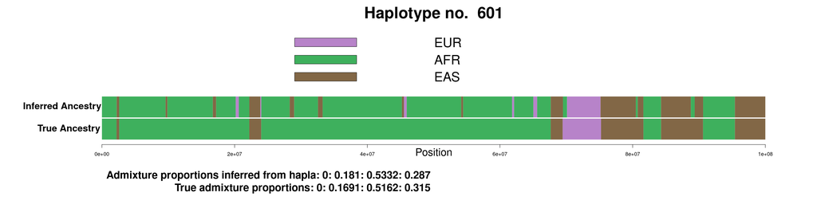

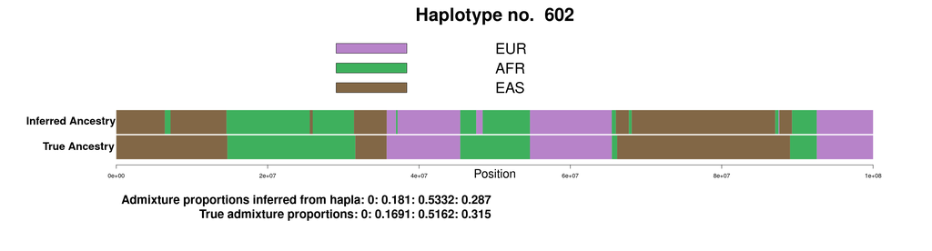

## What do you make of this result?

## Does it make any mistakes compared to the true ancestry? Any common type of error?

## Try looking at some more individuals by adjusting the code in the the last little loop of the code cell (set it to eg ."i in 601:610").

## Why does the index start at 601?

## Next try setting it to 1:10 instead

## Which individuals are shown now?

## What about 201:210?

## Now lets try to change some of our parameters to see if we can get a better estimate. In the following code Ive set the window size to 32 instead and lowered the lambda parameter from 0.125 to 0.05 to get more clusters per window, lets see what difference that makes:

```
hapla cluster --bcf simAA_maf.bcf --size 32 --threads 8 --out simAA_maf_wdsize32 --lmbda 0.05
hapla admix --clusters simAA_maf_wdsize32 --K 3 --seed 2 --threads 8 --out simAA_maf_wdsize32
hapla fatash --clusters simAA_maf_wdsize32 --qfile simAA_maf_wdsize32.K3.s2.Q --pfile simAA_maf_wdsize32.K3.s2.P --threads 8 --out simAA_maf_wdsize32
```

```
-----------------------------------
hapla by Jonas Meisner (v0.40.0)
hapla cluster using 8 thread(s)
-----------------------------------

Loaded phased genotype data: 800 haplotypes and 106171 SNPs.
Clustering 3317 non-overlapping windows of 32 SNPs.
Window 3317/3317.

Saved haplotype clusters in binary format:
- simAA_maf_wdsize32.bca
- simAA_maf_wdsize32.ids
- simAA_maf_wdsize32.win

Total parsing time: 0m2s
Total elapsed time: 0m23s
-----------------------------------
hapla by Jonas Meisner (v0.40.0)
hapla admix using 8 thread(s)
-----------------------------------
Estimating ancestry proportions.
K=3, seed=2, batches=16

Parsing 1 file(s).
Loaded haplotype cluster assignments:
- 400 samples
- 3317 windows
- 97074 clusters

SVD/ALS initialization.		(1.8s)
Initial log-like: -5958518.0
Priming iteration.		(0.0s)

Mini-batch accelerated EM algorithm.
Using 16 mini-batches.
(5)	Log-like: -5929922.6	(0.2s)
(10)	Log-like: -5929916.0	(0.2s)
(15)	Log-like: -5929917.0	(0.2s)
Halving mini-batches to 8.
(20)	Log-like: -5929895.1	(0.2s)
```

[output cut: 21 more lines]

```

Total elapsed time: 0m5s
-----------------------------------
hapla by Jonas Meisner (v0.40.0)
hapla fatash using 8 thread(s)
-----------------------------------

Parsing 1 file(s).
Inferring local ancestry tracts from 3 ancestral sources.
Processing file 1/1
Estimating file-specific ancestry proportions.		(1.0s)
Performing posterior decoding with majority voting across 5 alphas.
Saved posterior decoding path as simAA_maf_wdsize32.path

Total elapsed time: 0m3s
```

**Questions**

- This repeats the clustering with a window of 32 instead of 8. Are the ancestry tracts longer or shorter, and smoother or noisier?
- Which window size would you trust for dating the admixture?

```
popcols <- c("0" = "#b783c9", "1" = "#3eb05d", "2" = "#826746")

subset_hap <- function(haplo_index) {
    true_anc_sub <<- data.frame(pos = true_anc[true_anc["sample"] == haplo_index, ]$pos,
                               pop = true_anc[true_anc["sample"] == haplo_index, ]$population)
    true_anc_sub$len <<- c(diff(true_anc_sub$pos), seqlen - true_anc_sub[nrow(true_anc_sub), 1])

    hapla_sub <<- data.frame(pos = as.numeric(names(hapla)),
                            pop = unlist(hapla[haplo_index, ]))
    hapla_sub[1, 1] <<- 0
    hapla_sub <<- hapla_sub[c(1, 1 + which(diff(hapla_sub$pop) != 0)), ] ## only keep first instances of each pop in tract to remove redundancy and make plots look nicer
    hapla_sub$len <<- c(diff(hapla_sub$pos), seqlen - hapla_sub[nrow(hapla_sub), 1])

}


plot_hap <- function(haplo_index, remap) {
    subset_hap(haplo_index)
    ind_index <- (haplo_index + 1) %/% 2

    q <- read.table(list.files(pattern = "simAA_maf_wdsize32.K3.s2.Q")[1])
    admix_str <- "Admixture proportions inferred from hapla: "
    for (true_k in 0:(length(remap) - 1)) {
        inferred_k <- names(remap[remap == as.character(true_k)])

        admix_str <- paste0(
            admix_str,
            true_k, ": ",
            round(q[ind_index, as.numeric(inferred_k) + 1], 3)
        )
    }

    true_admix <- read.table("simAA_trueQ.csv", header = FALSE)
    true_admix_str <- "True admixture proportions: "
    for (i in 1:dim(q)[2]){
        true_admix_str <- paste0(true_admix_str, i - 1, ": ", round(true_admix[ind_index, i], 3))
    }


    plot(c(0, seqlen), c(0, 1), type = "n", main = paste("Haplotype no. ", haplo_index),
        ylab = "", yaxt = "n", xlab = "Position\n", cex.main = 3, cex.lab = 2, cex.sub = 3, bty="n")

    for (start in seq(1, nrow(hapla_sub))){
        segments(hapla_sub[start, 1], .3, hapla_sub[start + 1, 1], .3, col = popcols[as.character(hapla_sub[start, 2])], lend = 1, lwd = 64)
    }
    segments(hapla_sub[nrow(hapla_sub), 1], .3, seqlen, .3, col = popcols[as.character(hapla_sub[nrow(hapla_sub), 2])], lend = 1, lwd = 64)

    for (start in seq(1, nrow(true_anc_sub))){
        segments(true_anc_sub[start, 1], 0.1, true_anc_sub[start + 1, 1], 0.1, col = popcols[as.character(true_anc_sub[start, 2])], lend = 1, lwd = 64)
    }
    segments(true_anc_sub[nrow(true_anc_sub), 1], 0.1, seqlen, 0.1, col = popcols[as.character(true_anc_sub[nrow(true_anc_sub), 2])], lend = 1, lwd = 64)

    text(seqlen/2, -0.4, paste0(admix_str,  "\n", true_admix_str), xpd=T, cex=2, font=2, pos=2)
    text(-seqlen * 0.06, .3, "Inferred Ancestry",font=2, cex = 1.8, xpd=T)
    text(-seqlen * 0.05, .1, "True Ancestry",font=2, cex = 1.8, xpd=T)
    legend("top", legend = c("EUR", "AFR", "EAS"),
                   fill = popcols[1:length(unique(true_anc_sub$pop))],
                   cex = 2.5, bty="n")
}



###### read true path
true_anc <- read.table("simAA_true_anc.csv", header = TRUE)
true_anc["sample"] <- true_anc["sample"] + 1 ## change indexing from 0 to 1
names(true_anc)[2] <- "pos"

seqlen <- max(true_anc$right)
npop <- length(unique(true_anc$population))


###### read hapla path res
hapla <- read.table("simAA_maf_wdsize32.path", header = FALSE)
names(hapla) <- read.table("simAA_maf_wdsize32.win")[, 2]

## Order of Ks are inferred arbitrarily, so we have to adjust them to fit the true values
remap <- c("0"="1", "1"="2", "2"="0")
hapla[] <- lapply(hapla, function(x) {
    as.numeric(unname(remap[as.character(x)])) })


par(mar=c(12,12,4,4))
for (i in 601:610){
    plot_hap(i, remap)
}
```

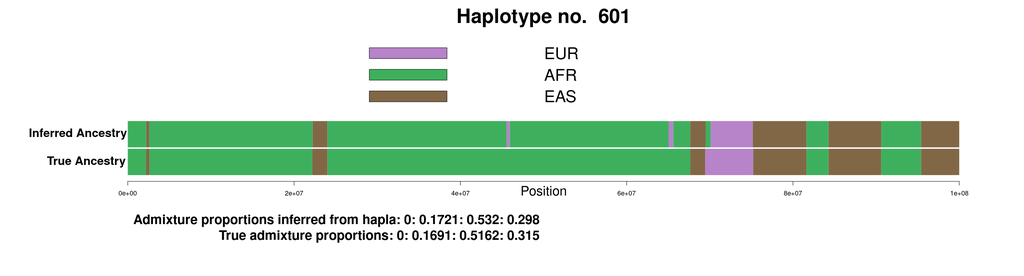

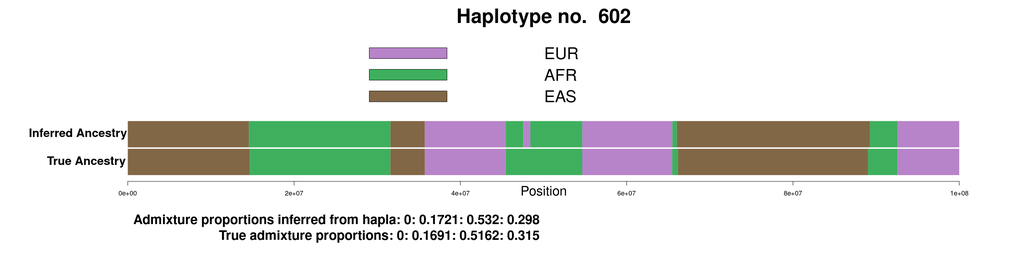

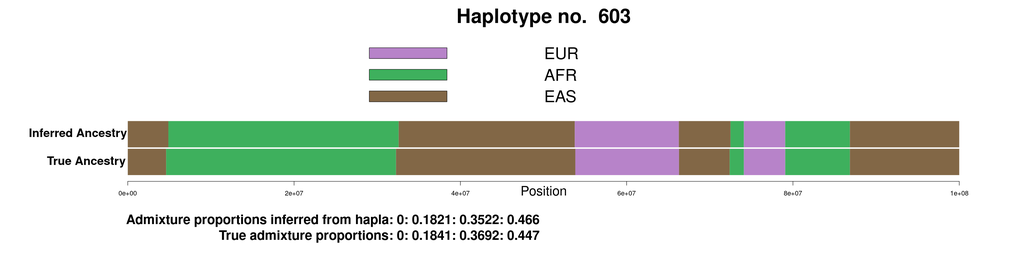

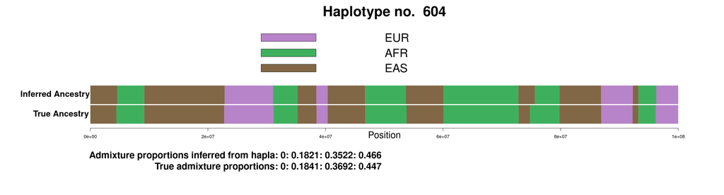

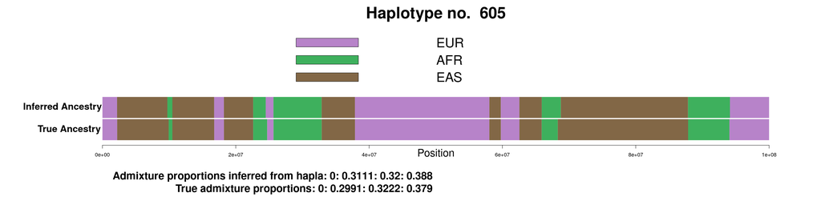

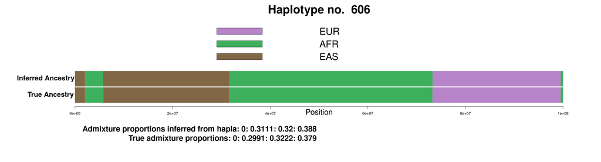

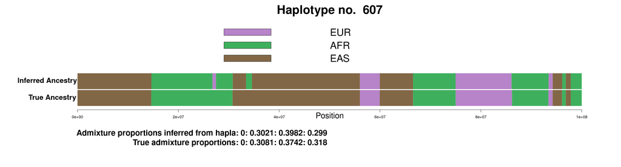

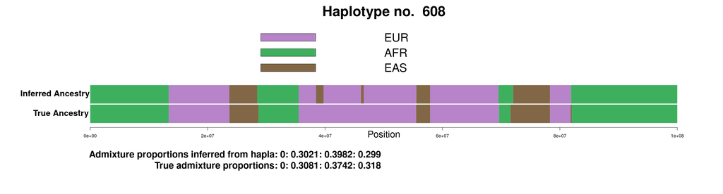

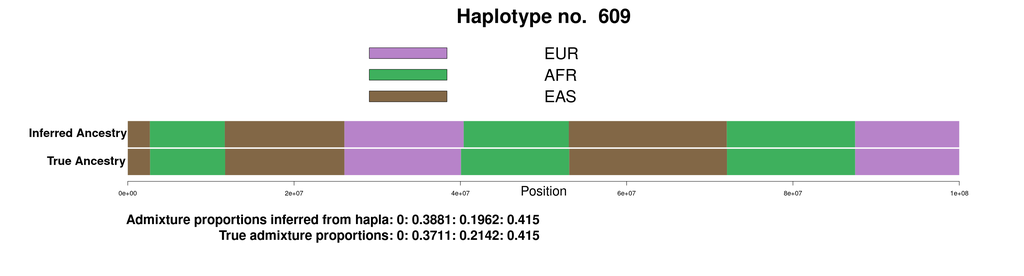

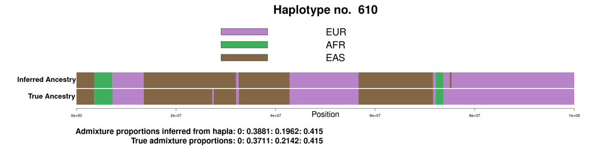

## Did this help, if so, why do you think?

## If you have time left try messing around with the parameters and see what changes (Note that the ordering of Ks might change and mess up the colors, you can fix this by changing the "remap" named vector in the plotting code or try out a different seed for the admixture part)

## If you have yet more time left you can also try changing the number of samples in the simulation to 10 for each of the unadmixed populations to see what happens to our inference and try to adjust parameters to see if you can get a better result.

```
## cow stuff
hapla cluster --bcf $CATTLE_BCF --size 256 --step 64 --threads 8 --out BosTau9
hapla admix --clusters BosTau9 --K 2 --seed 2 --threads 8 --out BosTau9
hapla fatash --clusters BosTau9 --qfile BosTau9.K2.s2.Q --pfile BosTau9.K2.s2.P --threads 8 --out BosTau9 --viterbi
```

```
-----------------------------------
hapla by Jonas Meisner (v0.40.0)
hapla cluster using 8 thread(s)
-----------------------------------

Loaded phased genotype data: 520 haplotypes and 961793 SNPs.
Clustering 15025 overlapping windows of 256 SNPs (step-size 64).
Window 15025/15025.

Saved haplotype clusters in binary format:
- BosTau9.bca
- BosTau9.ids
- BosTau9.win

Total parsing time: 0m10s
Total elapsed time: 0m56s
-----------------------------------
hapla by Jonas Meisner (v0.40.0)
hapla admix using 8 thread(s)
-----------------------------------
Estimating ancestry proportions.
K=2, seed=2, batches=16

Parsing 1 file(s).
Loaded haplotype cluster assignments:
- 260 samples
- 15025 windows
- 123190 clusters

SVD/ALS initialization.		(1.7s)
Initial log-like: -8306603.9
Priming iteration.		(0.1s)

Mini-batch accelerated EM algorithm.
Using 16 mini-batches.
(5)	Log-like: -8222159.7	(0.5s)
(10)	Log-like: -8222057.9	(0.4s)
(15)	Log-like: -8222054.0	(0.4s)
(20)	Log-like: -8222052.8	(0.4s)
(25)	Log-like: -8222051.4	(0.4s)
```

[output cut: 22 more lines]

```

Total elapsed time: 0m9s
-----------------------------------
hapla by Jonas Meisner (v0.40.0)
hapla fatash using 8 thread(s)
-----------------------------------

Parsing 1 file(s).
Inferring local ancestry tracts from 2 ancestral sources.
Processing file 1/1
Estimating file-specific ancestry proportions.		(2.3s)
Performing Viterbi decoding with majority voting across 5 alphas.
Saved Viterbi decoding path as BosTau9.path

Total elapsed time: 0m4s
```

**Questions**

- The same pipeline now runs on real cattle data with `--size 256 --step 64`. Why a much larger window than for the simulation?
- There is no truth to compare against here. How would you judge whether the result is sensible?

```
cat $CATTLE_INDS
```

```
N_31B
```

```
options(repr.plot.width = 26, repr.plot.height = 10)

popinfo <- read.table("BosTau9.ids", h=F)[,1]
Q <- read.table("BosTau9.K2.s2.Q", h=F)

par(mar=c(12,14,4,4), oma=c(0,10,0,0))

barplot(t(Q), col=c("#83c996", "#ed7551"), space=0, border=NA, cex.axis=1.2,cex.lab=1.8,axisnames=FALSE,
             ylab=paste0("Admixture proportions\nfor K = ", ncol(Q)), xlab="", main="", cex.main=1.5,xpd=NA)

nlabrows <- 26
text(1:nrow(Q), rep((-1:-nlabrows)*0.03,nrow(Q)/nlabrows), popinfo, xpd=NA,font=2,cex=0.8, adj=.03)
```

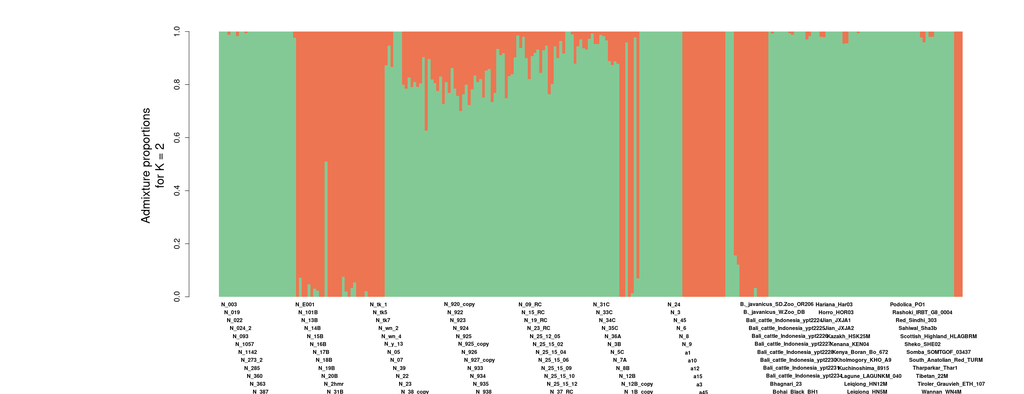

```
options(repr.plot.width = 26, repr.plot.height = 4)
popcols <- c("0" = "#83c996", "1" = "#ed7551")

subset_hap <- function(haplo_index) {
    hapla_sub <<- data.frame(pos = as.numeric(names(hapla)),
                            pop = unlist(hapla[haplo_index, ]))
    hapla_sub[1, 1] <<- 0
    hapla_sub <<- hapla_sub[c(1, 1 + which(diff(hapla_sub$pop) != 0)), ] ## only keep first instances of each pop in tract to remove redundancy and make plots look nicer
    hapla_sub$len <<- c(diff(hapla_sub$pos), seqlen - hapla_sub[nrow(hapla_sub), 1])

}


plot_hap <- function(haplo_index) {
    subset_hap(haplo_index)
    plot(c(0, seqlen), c(0, .2), type = "n", main = paste("Haplotype no. ", haplo_index),
        ylab = "", yaxt = "n", xlab = "Position\n", cex.main = 3, cex.lab = 2, cex.sub = 3, bty="n")

    for (start in seq(1, nrow(hapla_sub))){
        segments(hapla_sub[start, 1], .1, hapla_sub[start + 1, 1], .1, col = popcols[as.character(hapla_sub[start, 2])], lend = 1, lwd = 64)
    }
    segments(hapla_sub[nrow(hapla_sub), 1], .1, seqlen, .1, col = popcols[as.character(hapla_sub[nrow(hapla_sub), 2])], lend = 1, lwd = 64)

    text(-seqlen * 0.06, 1, "Inferred Ancestry",font=2, cex = 1.8, xpd=T)
#     legend("top", legend = c("EUR", "AFR", "EAS"),
#                    fill = popcols[1:length(unique(true_anc_sub$pop))],
#                    cex = 2.5, bty="n")
}


###### read hapla path res
hapla <- read.table("BosTau9.path", header = FALSE)
names(hapla) <- read.table("BosTau9.win")[, 2]
seqlen <- max(as.numeric(names(hapla)))

popinfo <- read.table("BosTau9.ids", h=F)[,1]
F1 <- which(popinfo=="N_31B")
admixed <- 129:150

par(mar=c(12,12,4,4))
for (i in c(F1*2-1, F1*2, admixed)){
    plot_hap(i)
}
```

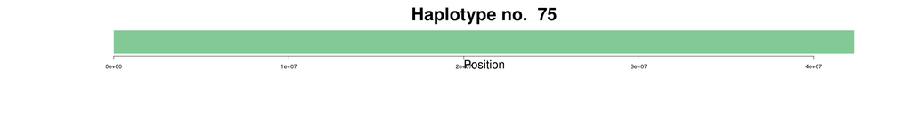

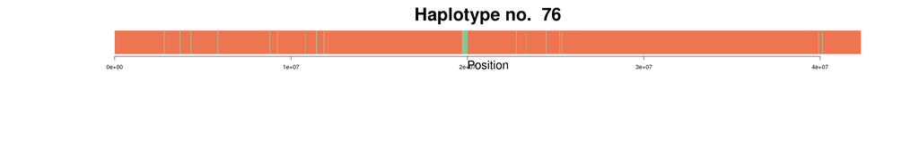

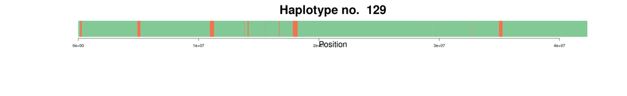

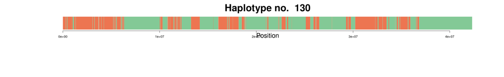

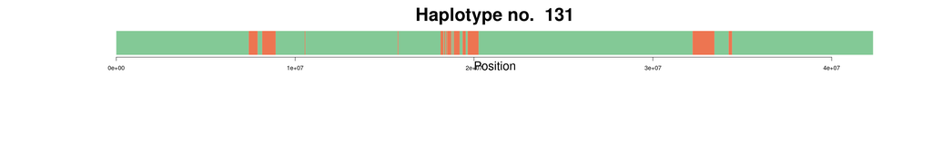

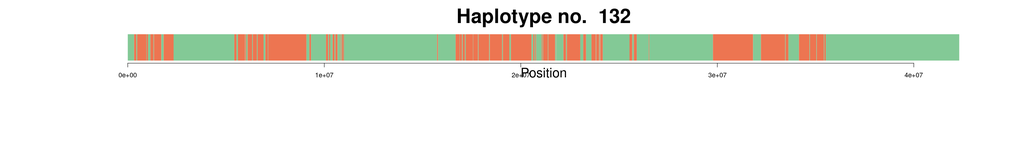

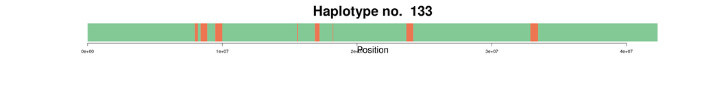

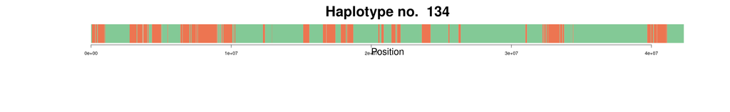

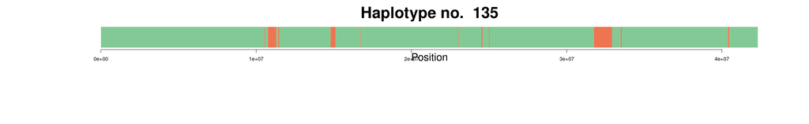

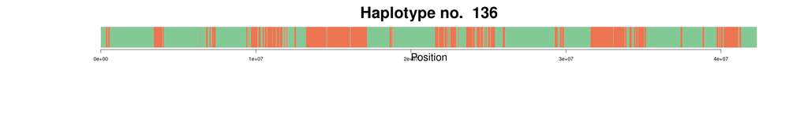

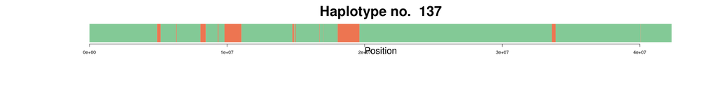

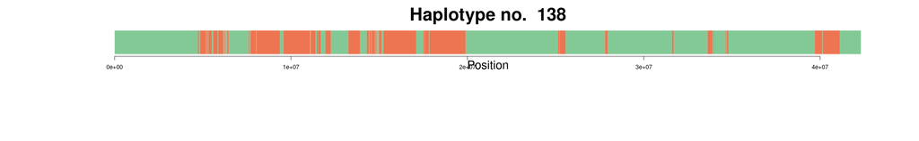

[12 more figures not shown]